# Assignment 12: Predictive Modeling - Part 3

*How to do it?*:

- Open the Rmarkdown file of this assignment (link) in Rstudio.
- Right under each **question**, insert a code chunk (you can use the hotkey `Ctrl + Alt + I` to add a code chunk) and code the solution for the question.
- `Knit` the rmarkdown file (hotkey: `Ctrl + Alt + K`) to export an html.
- Publish the html file to your Githiub Page.

*Submission*: Submit the link on Github of the assignment to Blackboard.

1. Install the package `mlbench` and use the follows to import the data

```r
library(mlbench)
data(PimaIndiansDiabetes)
df <- PimaIndiansDiabetes
```

- Set seed to be 2020.
- The target variable is `diabetes`
- Partition the data into 80% training and 20% testing.

```r
library(caret)
set.seed(2020)
splitIndex <- createDataPartition(df$diabetes, p = .80, list = FALSE)
df_train <- df[splitIndex,]
df_test <- df[-splitIndex,]
```

2. Use cross-validation of 30 folds to tune random forest (method=‘rf’). What is the `mtry` value that produces the greatest accuracy?

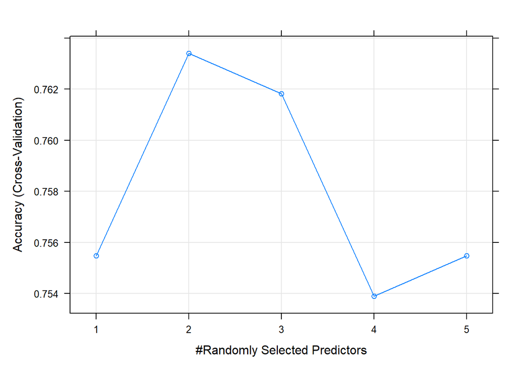

```r
trControl = trainControl(method = "cv", number = 30)
tuneGrid = expand.grid(mtry = 1:5)
forest_rf <- train(diabetes~., data=df_train, method = "rf", trControl = trControl, tuneGrid = tuneGrid)
plot(forest_rf)
```

3. Use cross-validation with of 30 folds to tune random forest (method=‘ranger’). What are the parameters that produce the greatest accuracy?

```r
getModelInfo('ranger')$ranger$parameters
```

```
##       parameter     class                         label
## 1          mtry   numeric #Randomly Selected Predictors
## 2     splitrule character                Splitting Rule
## 3 min.node.size   numeric             Minimal Node Size
```

```r
trControl = trainControl(method = "cv", number = 30)
tuneGrid = expand.grid(mtry = 1:5, splitrule = c('gini', 'extratrees'), min.node.size = c(1:10))
forest_ranger <- train(diabetes~., data=df_train, method = "ranger", trControl = trControl, tuneGrid = tuneGrid)
```

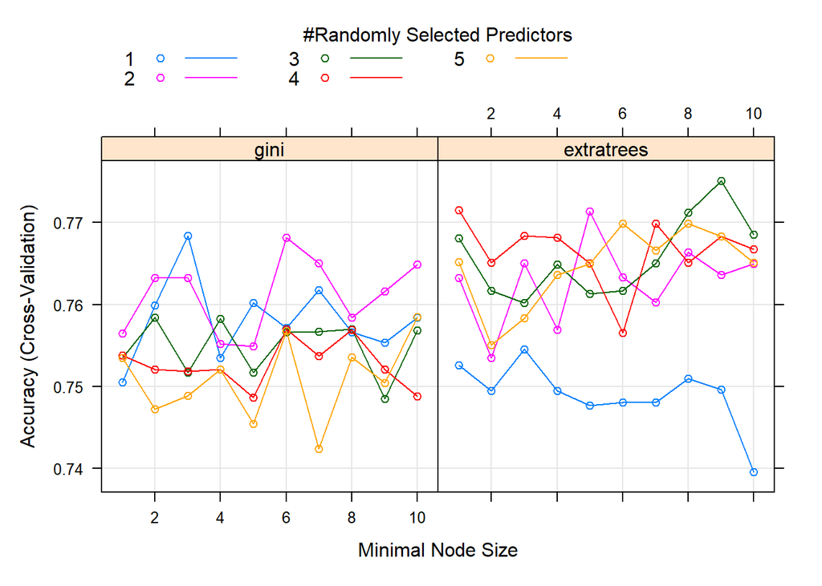

```r
plot(forest_ranger)
```

4. Go to https://topepo.github.io/caret/available-models.html and pick a classification model. Tune the classification model using cross-validation of 30 folds.

```r
trControl = trainControl(method = "cv", number = 30)
tuneGrid = expand.grid(mfinal = 5, maxdepth = 1:5)
forest_step <- train(diabetes~., data=df_train, method = "AdaBag", trControl = trControl, tuneGrid = tuneGrid)
```

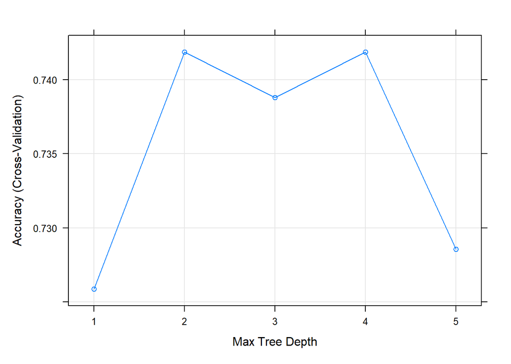

```r
plot(forest_step)
```

5. Pick three models at [this link](https://topepo.github.io/caret/available-models.html) to compare using 15-fold cross validation method. Evaluate the accuracy of the final model on the test data. What is the best model?

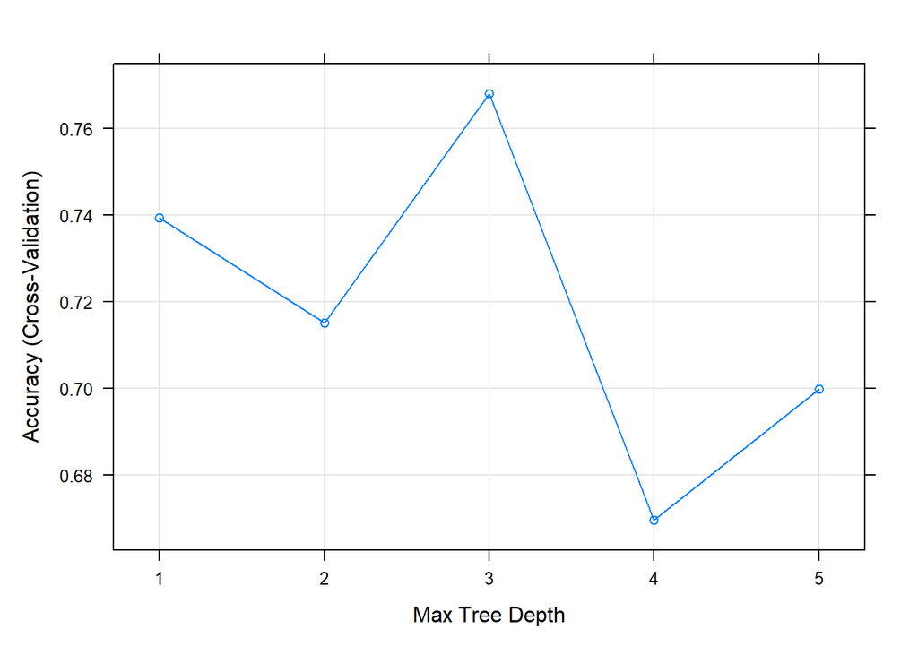

```r
trControl = trainControl(method = "cv", number = 15)
tuneGrid = expand.grid(mfinal = 5, maxdepth = 1:5)
forest_step1 <- train(diabetes~., data=df_test, method = "AdaBag", trControl = trControl, tuneGrid = tuneGrid)
plot(forest_step1)
```

```r
trControl = trainControl(method = "cv", number = 15)
tuneGrid = expand.grid(degree = 3, nprune = 1:5)
forest_fda <- train(diabetes~., data=df_test, method = "fda", trControl = trControl, tuneGrid = tuneGrid)
```

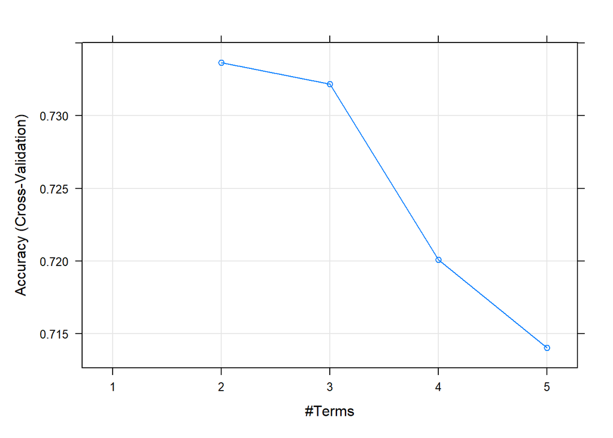

```r
plot(forest_fda)
```

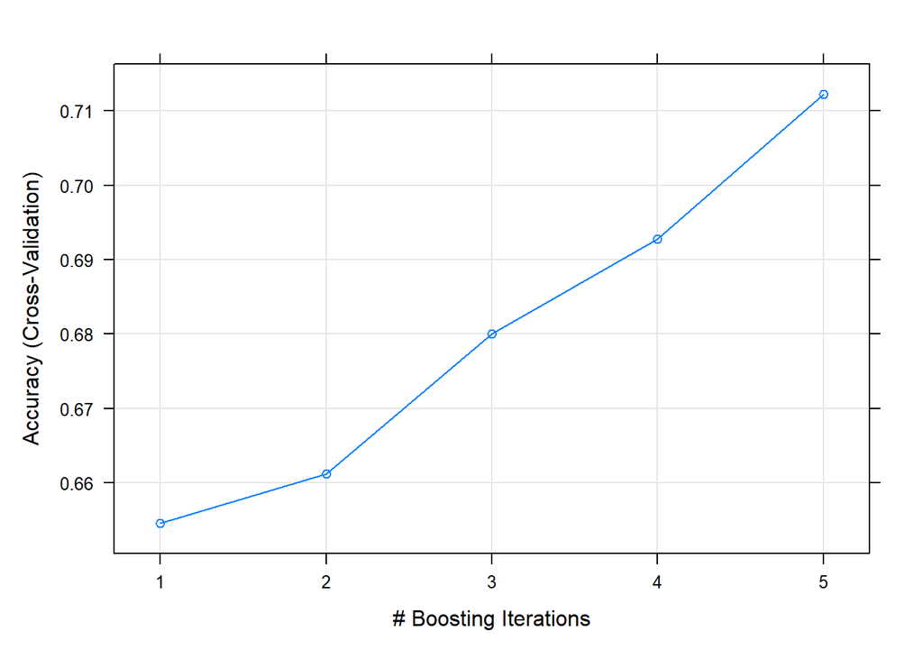

```r
trControl = trainControl(method = "cv", number = 15)
tuneGrid = expand.grid(mstop = 1:5, prune = 5)
forest_glm <- train(diabetes~., data=df_test, method = "glmboost", trControl = trControl, tuneGrid = tuneGrid)
plot(forest_glm)
```

6. Redo Question 5 on this following dataset.
- `Adult Census Income` dataset ([Link](https://www.kaggle.com/uciml/adult-census-income)) where the target variable is `income`

```r
library(tidyverse)
a <- read_csv('adult.csv')
library(caret)
set.seed(2020)
splitIndex <- createDataPartition(a$income, p = .80, list = FALSE)
a_train <- a[splitIndex,]
a_test <- a[-splitIndex,]
```

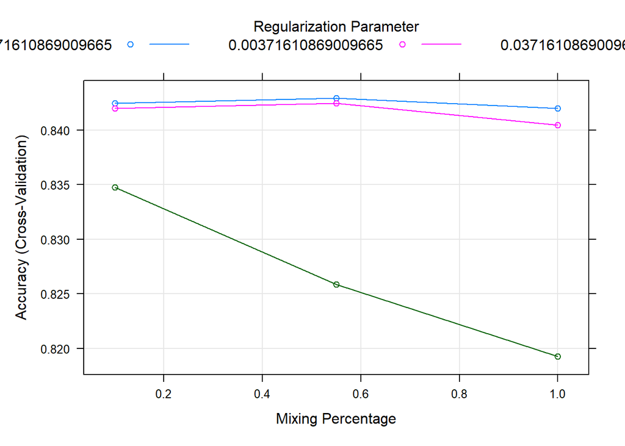

```r
trControl = trainControl(method = "cv", number = 15)
forest_glm1 <- train(income~., data=a_test, method = "glmnet", trControl = trControl)
plot(forest_glm1)
```

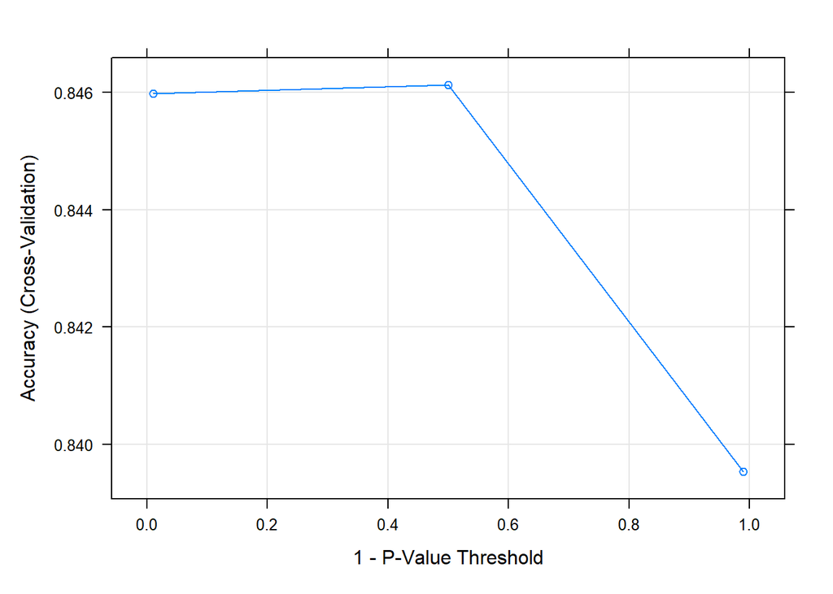

```r
trControl = trainControl(method = "cv", number = 15)
forest_ctree <- train(income~., data=a_test, method = "ctree", trControl = trControl)
plot(forest_ctree)
```

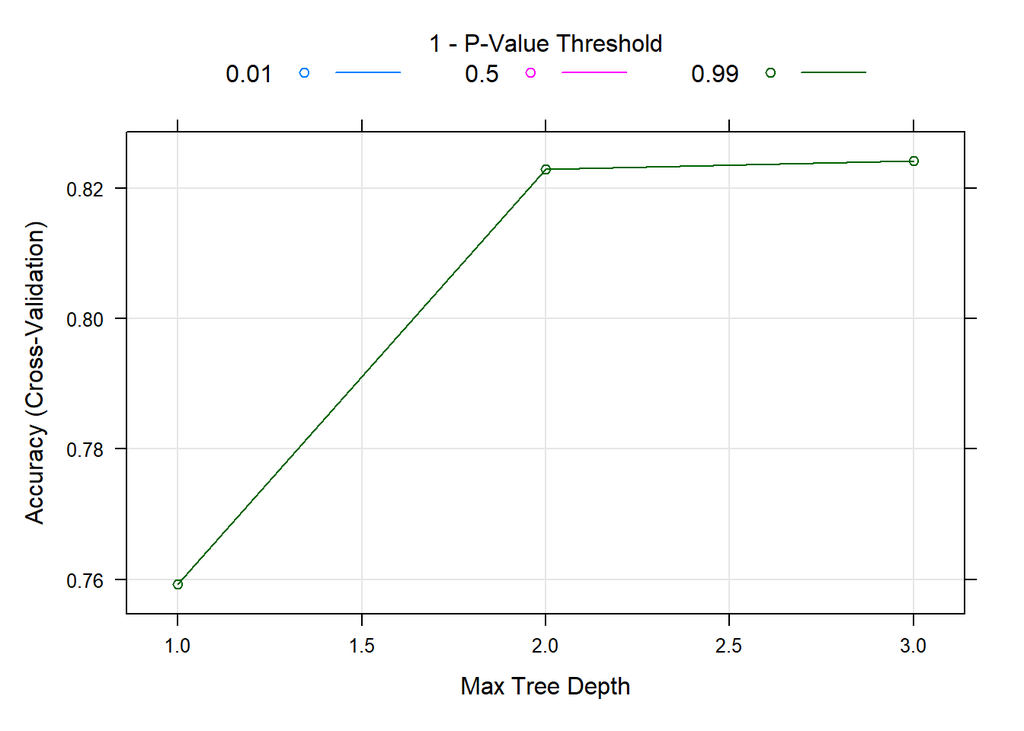

```r
trControl = trainControl(method = "cv", number = 15)
forest_ctree2 <- train(income~., data=a_test, method = "ctree2", trControl = trControl)
plot(forest_ctree2)
```

- `Credit card default` dataset ([link](https://www.kaggle.com/uciml/default-of-credit-card-clients-dataset)) where the target variable is `default.payment.next.month`

```r
library(tidyverse)
b <- read_csv('UCI_Credit_Card.csv')
library(caret)
set.seed(2020)
splitIndex <- createDataPartition(b$default.payment.next.month, p = .80, list = FALSE)
b_train <- b[splitIndex,]
b_test <- b[-splitIndex,]
```